# Brexit Poll Analysis

# Overview

In June 2016, the United Kingdom (UK) held a referendum to determine whether the country would “Remain” in the European Union (EU) or “Leave” the EU. This referendum is commonly known as Brexit. Although the media and others interpreted poll results as forecasting “Remain” ( 𝑝>0.5) , the actual proportion that voted “Remain” was only 48.1% (𝑝=0.481) and the UK thus voted to leave the EU. Pollsters in the UK were criticized for overestimating support for “Remain”. In this project, you will analyze real Brexit polling data to develop polling models to forecast Brexit results.

```r
library(tidyverse)
library(dslabs)
data(brexit_polls)
options(digits = 3)
```

Define p=0.481 as the actual percent voting for “Remain”. The spread being 2p-1.

```r
p <- 0.481
d <- 2*p - 1
```

Considering a poll of 1500 voters, the real values of sample parameters are:-

```r
N <- 1500
expected <- N*p #expected total number of voters in the sample choosing “Remain”
expected
```

```
[1] 722
```

```r
se_remain <- sqrt(N*p*(1-p)) #standard error of the total number of voters in the sample choosing “Remain”
se_remain
```

```
[1] 19.4
```

```r
x_hat <- p #expected value of X_hat , the proportion of “Remain” voters
x_hat
```

```
[1] 0.481
```

```r
standard_error_x_hat <- sqrt(x_hat * (1-x_hat)/N)
se_d <- 2 * standard_error_x_hat
```

### Actual Brexit poll estimates

Load and inspect the brexit_polls dataset from dslabs, which contains actual polling data for the 6 months before the Brexit vote. Raw proportions of voters preferring “Remain”, “Leave”, and “Undecided” are available (remain, leave, undecided) The spread is also available (spread), which is the difference in the raw proportion of voters choosing “Remain” and the raw proportion choosing “Leave”.

```r
head(brexit_polls)
```

|  | startdate | enddate | pollster | poll_type | samplesize | remain | leave | undecided | spread |
| --- | --- | --- | --- | --- | --- | --- | --- | --- | --- |
| 1 | 2016-06-23 | 2016-06-23 | YouGov | Online | 4772 | 0.52 | 0.48 | 0.00 | 0.04 |
| 2 | 2016-06-22 | 2016-06-22 | Populus | Online | 4700 | 0.55 | 0.45 | 0.00 | 0.10 |
| 3 | 2016-06-20 | 2016-06-22 | YouGov | Online | 3766 | 0.51 | 0.49 | 0.00 | 0.02 |
| 4 | 2016-06-20 | 2016-06-22 | Ipsos MORI | Telephone | 1592 | 0.49 | 0.46 | 0.01 | 0.03 |
| 5 | 2016-06-20 | 2016-06-22 | Opinium | Online | 3011 | 0.44 | 0.45 | 0.09 | -0.01 |
| 6 | 2016-06-17 | 2016-06-22 | ComRes | Telephone | 1032 | 0.54 | 0.46 | 0.00 | 0.08 |

The average and standard deviation of the observed spreads is given by

```r
polls <- brexit_polls %>%
  mutate(x_hat = (spread+1)/2)
mean(polls$spread)
```

```
[1] 0.0201
```

```r
sd(polls$spread)
```

```
[1] 0.0588
```

The average and standard deviation of x_hat

```r
mean(polls$x_hat)
```

```
[1] 0.51
```

```r
sd(polls$x_hat)
```

```
[1] 0.0294
```

### Confidence interval of a Brexit poll

Consider the first poll in brexit_polls, a YouGov poll run on the same day as the Brexit referendum:

```r
you_gov <- polls[1, ]
```

We compute the 95% confidence interval for the poll.

```r
avg <- you_gov$x_hat
N <- you_gov$samplesize

se <- sqrt(avg*(1-avg)/N)
avg + c(-1,1) * qnorm(0.975)*se
```

```
[1] 0.506 0.534
```

We see that the poll is 95% confident that the result will be in the range (0.506, 0.534) that is “Remain”.

### Confidence intervals for polls in June

Create the data frame june_polls containing only Brexit polls ending in June 2016 (enddate of “2016-06-01” and later). We will calculate confidence intervals for all polls and determine how many cover the true value of d.

First, use mutate() to calculate a plug-in estimate se_x_hat for the standard error of the estimate SE for each poll given its sample size and value of X_hat. Second, we use mutate() to calculate an estimate for the standard error of the spread for each poll given the value of se_x_hat. Then, we use mutate() to calculate upper and lower bounds for 95% confidence intervals of the spread. Last, add a column hit that indicates whether the confidence interval for each poll covers the correct spread 𝑑=−0.038.

```r
june_polls <- polls %>%
  filter(enddate>="2016-06-1")
head(june_polls)
```

|  | startdate | enddate | pollster | poll_type | samplesize | remain | leave | undecided | spread | x_hat |
| --- | --- | --- | --- | --- | --- | --- | --- | --- | --- | --- |
| 1 | 2016-06-23 | 2016-06-23 | YouGov | Online | 4772 | 0.52 | 0.48 | 0.00 | 0.04 | 0.520 |
| 2 | 2016-06-22 | 2016-06-22 | Populus | Online | 4700 | 0.55 | 0.45 | 0.00 | 0.10 | 0.550 |
| 3 | 2016-06-20 | 2016-06-22 | YouGov | Online | 3766 | 0.51 | 0.49 | 0.00 | 0.02 | 0.510 |
| 4 | 2016-06-20 | 2016-06-22 | Ipsos MORI | Telephone | 1592 | 0.49 | 0.46 | 0.01 | 0.03 | 0.515 |
| 5 | 2016-06-20 | 2016-06-22 | Opinium | Online | 3011 | 0.44 | 0.45 | 0.09 | -0.01 | 0.495 |
| 6 | 2016-06-17 | 2016-06-22 | ComRes | Telephone | 1032 | 0.54 | 0.46 | 0.00 | 0.08 | 0.540 |

```r
d <- -0.38
june_polls <- june_polls %>%
  mutate(se_x_hat = sqrt(x_hat * (1-x_hat)/ samplesize), se_spread = 2*se_x_hat,
         lower = spread - qnorm(0.975) * se_spread,
         upper = spread + qnorm(0.975) * se_spread,
         hit = (lower < 2*p-1 & upper > 2*p-1))
mean(june_polls$lower < 0 & june_polls$upper > 0) #proportion of polls that had a 0 in their prediction
```

```
[1] 0.625
```

```r
mean(june_polls$hit) #avg hitrate
```

```
[1] 0.562
```

```r
head(june_polls)
```

|  | startdate | enddate | pollster | poll_type | samplesize | remain | leave | undecided | spread | x_hat | se_x_hat | se_spread | lower | upper | hit |
| --- | --- | --- | --- | --- | --- | --- | --- | --- | --- | --- | --- | --- | --- | --- | --- |
| 1 | 2016-06-23 | 2016-06-23 | YouGov | Online | 4772 | 0.52 | 0.48 | 0.00 | 0.04 | 0.520 | 0.00723 | 0.0145 | 0.0117 | 0.0683 | FALSE |
| 2 | 2016-06-22 | 2016-06-22 | Populus | Online | 4700 | 0.55 | 0.45 | 0.00 | 0.10 | 0.550 | 0.00726 | 0.0145 | 0.0716 | 0.1284 | FALSE |
| 3 | 2016-06-20 | 2016-06-22 | YouGov | Online | 3766 | 0.51 | 0.49 | 0.00 | 0.02 | 0.510 | 0.00815 | 0.0163 | -0.0119 | 0.0519 | FALSE |
| 4 | 2016-06-20 | 2016-06-22 | Ipsos MORI | Telephone | 1592 | 0.49 | 0.46 | 0.01 | 0.03 | 0.515 | 0.01253 | 0.0251 | -0.0191 | 0.0791 | FALSE |
| 5 | 2016-06-20 | 2016-06-22 | Opinium | Online | 3011 | 0.44 | 0.45 | 0.09 | -0.01 | 0.495 | 0.00911 | 0.0182 | -0.0457 | 0.0257 | TRUE |
| 6 | 2016-06-17 | 2016-06-22 | ComRes | Telephone | 1032 | 0.54 | 0.46 | 0.00 | 0.08 | 0.540 | 0.01551 | 0.0310 | 0.0192 | 0.1408 | FALSE |

### Hit rate by pollster

To find the proportion of hits for each pollster and the number of polls per pollster.

```r
june_polls_grouped <- june_polls %>%
  group_by(pollster) %>%
  summarize(n_polls = n(), hits = sum(hit))
june_polls_grouped
```

| pollster | n_polls | hits |
| --- | --- | --- |
| BMG Research | 2 | 0 |
| ComRes | 3 | 1 |
| ICM | 3 | 3 |
| Ipsos MORI | 2 | 1 |
| Opinium | 3 | 2 |
| ORB | 3 | 2 |
| ORB/Telegraph | 1 | 0 |
| Populus | 1 | 0 |
| Survation | 2 | 1 |
| Survation/IG Group | 1 | 1 |

[output cut: 2 more lines]

### Boxplot of Brexit polls by poll type

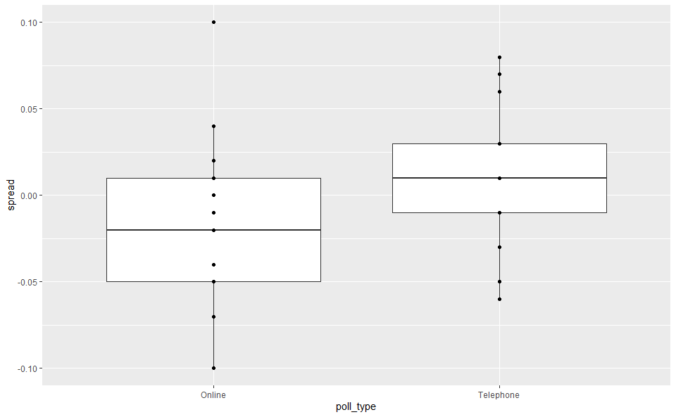

```r
ggplot(june_polls, aes(poll_type, spread))+
  geom_boxplot()+
  geom_point()
```

### Combined spread across poll type

We Calculate the confidence intervals of the spread combined across all polls in june_polls, grouping by poll type. To determine the standard error of the spread, we will need to double the standard error of the estimate.

```r
combined_by_type <- june_polls %>%
        group_by(poll_type) %>%
        summarize(N = sum(samplesize),
                  spread = sum(spread*samplesize)/N,
                  p_hat = (spread + 1)/2,
                  se_spread = 2 * sqrt(p_hat*(1-p_hat)/N),
                  lower = spread - qnorm(0.975) * se_spread,
                  upper = spread + qnorm(0.975) * se_spread)
combined_by_type
```

| poll_type | N | spread | p_hat | se_spread | lower | upper |
| --- | --- | --- | --- | --- | --- | --- |
| Online | 46711 | -0.00741 | 0.496 | 0.00463 | -0.01648 | 0.00165 |
| Telephone | 13490 | 0.01273 | 0.506 | 0.00861 | -0.00414 | 0.02961 |

### Chi-squared p-value test

The following code computes the confidence intervals for all Brexit polls in 2016 and then calculates whether the confidence interval covers the actual value of the spread 𝑑=−0.038 :

```r
brexit_hit <- brexit_polls %>%
  mutate(p_hat = (spread + 1)/2,
         se_spread = 2*sqrt(p_hat*(1-p_hat)/samplesize),
         spread_lower = spread - qnorm(.975)*se_spread,
         spread_upper = spread + qnorm(.975)*se_spread,
         hit = spread_lower < -0.038 & spread_upper > -0.038) %>%
  select(poll_type, hit)
```

We use brexit_hit to make a two-by-two table of poll type and hit status. Then use the chisq.test() function to perform a chi-squared test to determine whether the difference in hit rate is significant.

What is the p-value of the chi-squared test comparing the hit rate of online and telephone polls?

```r
totals <- brexit_hit%>%
  summarize(online_yes=sum(poll_type=="Online" & hit==TRUE),
            online_no=sum(poll_type=="Online" & hit==FALSE),
            tele_yes=sum(hit==TRUE & poll_type=='Telephone'),
            tele_no=sum(hit == FALSE & poll_type == 'Telephone'))
totals
```

| online_yes | online_no | tele_yes | tele_no |
| --- | --- | --- | --- |
| 48 | 37 | 10 | 32 |

```r
two_by_two <- tibble(hit = c('yes','no'),
                     online = c(totals$online_yes, totals$online_no),
                     telephone = c(totals$tele_yes, totals$tele_no))
two_by_two
```

| hit | online | telephone |
| --- | --- | --- |
| yes | 48 | 10 |
| no | 37 | 32 |

```r
chisq_test <- two_by_two %>% select(-hit) %>% chisq.test()
chisq_test
```

```
    Pearson's Chi-squared test with
    Yates' continuity correction

data:  .
X-squared = 11, df = 1, p-value =
0.001
```

```r
online_yes_odds <- (two_by_two$online[1] / sum(two_by_two$online)) / (two_by_two$online[2] / sum(two_by_two$online))
online_yes_odds
```

```
[1] 1.3
```

```r
telephone_yes_odds <- (two_by_two$telephone[1] / sum(two_by_two$telephone)) / (two_by_two$telephone[2] / sum(two_by_two$telephone))
telephone_yes_odds
```

```
[1] 0.312
```

```r
online_yes_odds / telephone_yes_odds
```

```
[1] 4.15
```

The odds are for online polls to hit versus telephone polls are 4.15 larger.

### Plotting spread over time

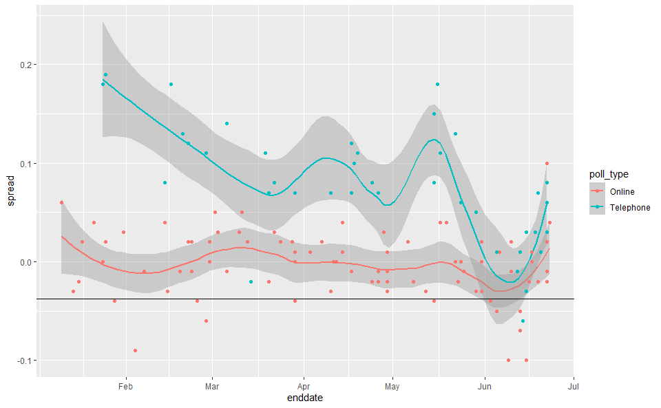

```r
brexit_polls %>%
  ggplot(aes(enddate, spread, color=poll_type))+
  geom_smooth(method = "loess", span=0.4)+
  geom_point(aes(color=poll_type))+
  geom_hline(yintercept = -0.038)
```

### Plotting raw percentages over time

```r
brexit_long <- brexit_polls %>%
    gather(vote, proportion, "remain":"undecided") %>%
    mutate(vote = factor(vote))
head(brexit_long)
```

|  | startdate | enddate | pollster | poll_type | samplesize | spread | vote | proportion |
| --- | --- | --- | --- | --- | --- | --- | --- | --- |
| 1 | 2016-06-23 | 2016-06-23 | YouGov | Online | 4772 | 0.04 | remain | 0.52 |
| 2 | 2016-06-22 | 2016-06-22 | Populus | Online | 4700 | 0.10 | remain | 0.55 |
| 3 | 2016-06-20 | 2016-06-22 | YouGov | Online | 3766 | 0.02 | remain | 0.51 |
| 4 | 2016-06-20 | 2016-06-22 | Ipsos MORI | Telephone | 1592 | 0.03 | remain | 0.49 |
| 5 | 2016-06-20 | 2016-06-22 | Opinium | Online | 3011 | -0.01 | remain | 0.44 |
| 6 | 2016-06-17 | 2016-06-22 | ComRes | Telephone | 1032 | 0.08 | remain | 0.54 |

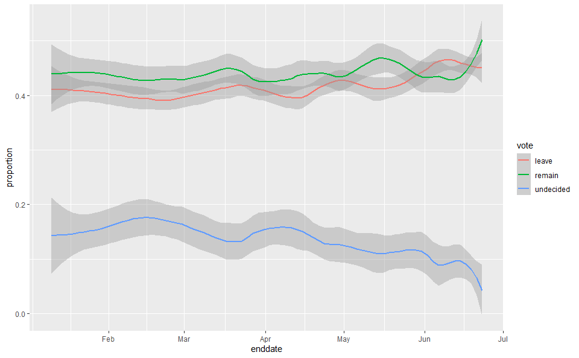

```r
brexit_long %>%
  ggplot(aes(enddate, proportion, color=vote))+
           geom_smooth(method = "loess", span=0.3)
```

```r
NA
```